# Building an R Package

From Scripts to Standardized Open-Source Tools

David Munoz Tord - Senior R Developer

david.tord@cytel.com

Cytel FSP - Johnson & Johnson Innovative Medicine

September 11, 2025

## Life in Pharma: Tables, Tables Everywhere

[figure not shown]

## Case Study: `junco` Clinical Trial Analysis Package

[figure not shown]

Example transformation of repetitive clinical trial analysis scripts:

1. **Identify common functions** across multiple studies
2. **Standardize input/output formats**
3. **Create consistent documentation**
4. **Implement validation tests**
5. **Open Sourcing**

## Challenges in Pharmaceutical Programming

- The pharmaceutical industry faces unique challenges in clinical and statistical programming:
- **Implementing patterns** used across many table shells (developed by dedicated teams)
- **Company-specific statistical methods** that need to be standardized
- **Complex table structures** that must be consistent across studies
- **Need for a core framework** that ensures all company shells can be created consistently
- → that where I step in !

## Shells Are Table Specific, Table Creation Is Not

### The Junco Package Approach

Our solution was to develop our own business logic framework for J&J table creation

[figure not shown]

## Getting to Production

The Junco package provides **key features** needed for production-ready clinical tables:

- **True-type font support**: Word wrapping, pagination, and RTF export
- **Higher order column counts**: Utilities for spanning column headers
- **Guaranteed pathability in row space**
- **Nearest-value (SAS-like) rounding support**: Maintaining consistency with existing processes
- **Statistical calculations**: In accord with business logic
- **Robust approach for risk diff columns**

## Limitations of Script-Based Solutions

- **Poor portability**: Hardcoded paths and environment-specific settings
- **Code duplication**: Functions often copied across multiple scripts
- **Reload overhead**: Need to source entire scripts even when only one function is needed
- No tools for **documentation**, **testing** and **difficult version tracking**

**Impact on Productivity**

When standardized code is distributed as scripts, users spend significant time troubleshooting environment issues, manually tracking versions, and repeatedly reloading large files for small changes.

## Creating a Package/Library

### Code Design and API for Users

- **User-friendly API**: Creating intuitive functions that match users’ mental models
- **Consistent interfaces**: Ensuring functions work together seamlessly
- **Clear documentation**: Making the package accessible to non-developers

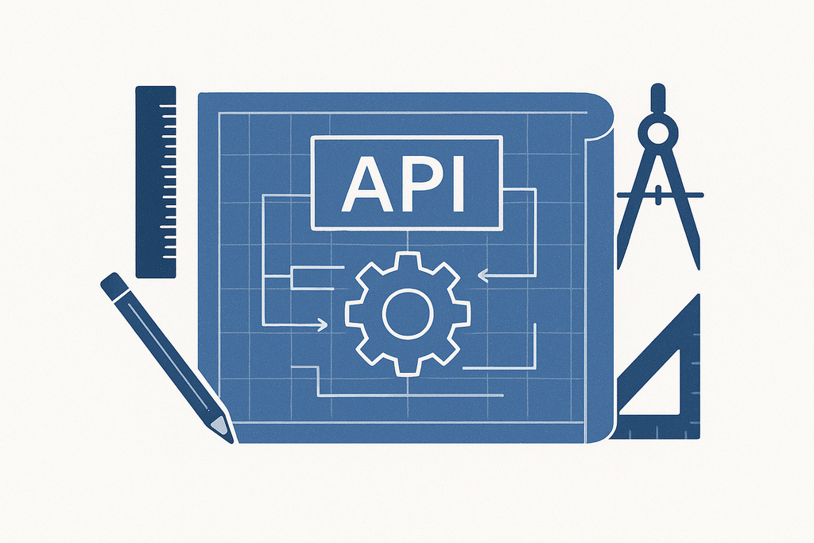

**Note**

API design is one of the most critical and challenging aspects of writing good code

## Documentation

### Using roxygen2 and pkgdown

Documentation is critical for package adoption and proper use:

1. **roxygen2 for function documentation**:

```r
#' Calculate risk difference with confidence intervals
#'
#' @param group1 Vector of outcomes for first group
#' @param group2 Vector of outcomes for second group
#' @param conf.level Confidence level (default: 0.95)
#' @return A list with risk difference and Cis
#' @export
risk_diff <- function(group1, group2, conf.level = 0.95) {
 # Function implementation
}
```

2. **pkgdown for website generation**:

```r
usethis::use_pkgdown()
pkgdown::build_site()
```

[interactive chart not shown]

## Ensuring Package Quality

### Unit Testing and Validation

Quality assurance is essential for pharmaceutical applications:

- **Unit tests**: Verify each function works as expected
- **Code coverage**: Metric that measures the percentage of your package’s code executed by your tests: [junco’s coverage](https://johnsonandjohnson.github.io/junco/_xml_coverage_reports/coverage.html)
- **Integration tests**: Ensure components work together correctly

```r
# Basic unit testing example
add_values <- function(x, y) {
  return(x + y)
}

library(testthat)

test_that("1: addition works", {
  expect_equal(add_values(2, 2), 4)
})
```

```
Test passed
```

```r
test_that("2: we do expected an error", {
   expect_error(add_values("a", 1))
})
```

```
Test passed
```

# Advanced Topics

## Continuous Integration and Deployment (CI/CD)

### Automating Quality Checks

CI/CD reduces manual work while improving quality:

- **Automated testing**: Run tests on every code change
- **Style checking**: Maintain consistent coding standards
- **Documentation building**: Keep documentation in sync with code

→ Our [GitHub actions](https://github.com/johnsonandjohnson/junco/actions/runs/16960522080)

**Note**

Also available internally with Jenkins (but MUCH more effort and knowledge needed)

## Development and Debugging Tools

### Enhanced Development Experience

Package structure enables seamless integration with powerful tools:

- **devtools/usethis**: Streamlined package development workflow
- **CodeDepends**: Analyze code dependencies and structure
- **pkgnet**: Visualize package structure and dependencies
- **lintr/styler**: Enforce coding standards automatically
- **profvis**: Profile and optimize package performance

```r
# Example: Package structure visualization
library(pkgnet)
CreatePackageReport("junco")
```

[`junco` package report](https://munoztd0.github.io/R_Package-Dev/junco_report.html)

**Development Efficiency**

These tools are designed to work with the standardized structure of R packages, providing insights and automation.

## What about Shiny Apps ?

- **Structure**: Organized code is easier to maintain
- **Modularity**: Reuse components across apps
- **Testing**: Leverage R’s testing infrastructure
- **Production-readiness**: Deployment and scaling

Framework options:

- [**golem**](https://thinkr-open.github.io/golem/): Opinionated, full app-as-package workflow (dev/ scripts, CI, tests, deployment)
- [**leprechaun**](https://leprechaun.opifex.org/#/): Lighter, code generator for simple Shiny app-packages with JS/Sass support
- [**rhino**](https://appsilon.github.io/rhino/): Pharma-oriented, uses box modules, not a package but package-like structure

**Framework Selection**

Choose based on complexity: golem (robust), leprechaun (lean), rhino (enterprise).

## Version Control and Collaboration

### Best Practices for Team Development

Effective collaboration requires good processes:

- **Semantic versioning**: Major.Minor.Patch format (`junco` v0.1.1)
- **Git branching strategy**: Feature branches and pull requests
- **Code review**: Ensure quality and knowledge sharing
- **Issue tracking**: Document bugs and feature requests → [issue #45](https://github.com/johnsonandjohnson/junco/issues/45#issuecomment-3200786303)

## Internal vs. External Packages

### Choosing the Right Distribution Method

Different distribution methods serve different needs:

- **Internal packages**: Company-specific methods, proprietary algorithms
- **GitHub packages**: Community collaboration, rapid development
- **CRAN packages**: General-purpose tools, widely applicable methods → integrable with SPACE and package validation processes
- **Pharmaceutical Considerations**

  Internal packages often contain proprietary methods or company-specific workflows that shouldn’t be publicly shared, while more general statistical methods may benefit from community review through CRAN or GitHub distribution.

## Open Sourcing in Pharma

### Why Joining Efforts is More Efficient

- **Standardization**: Common tools lead to more consistent and comparable analyses
- **Reduced duplication**: Companies avoid solving the same problems repeatedly
- **Shared maintenance burden**: Multiple companies contribute to maintaining core infrastructure
- **Broader testing**: Diverse use cases identify edge cases and bugs more effectively

**Industry Transformation**

The pharmaceutical industry is increasingly recognizing that pre-competitive collaboration on analytical tools benefits everyone. Projects like the R Validation Hub and Pharmaverse demonstrate how shared open source efforts can accelerate innovation while reducing costs.

## Demo: Creating Complex Tables with Junco

### Table Creation Script

```r
library(junco)
library(dplyr)
library(pharmaverseadamjnj)

ADEG <- pharmaverseadamjnj::adeg |>
  select(STUDYID, USUBJID, TRT01A, PARAM, AVISIT, AVAL, CHG) |>
  filter(PARAM == "ECG Mean Heart Rate (beats/min)") |>

  mutate(colspan_trt = factor(
    if_else(TRT01A == "Placebo", " ", "Active Study Agent"),
    levels = c("Active Study Agent", " ")
  )) |>

  mutate(rrisk_header = "Risk Difference (%) (95% CI)") |>
  mutate(rrisk_label = paste(TRT01A, paste("vs", "Placebo")))

colspan_trt_map <- create_colspan_map(ADEG,
  non_active_grp = "Placebo",
  non_active_grp_span_lbl = " ",
  active_grp_span_lbl = "Active Study Agent",
  colspan_var = "colspan_trt",
  trt_var = "TRT01A"
)
ref_path <- c("colspan_trt", " ", "TRT01A", "Placebo")

lyt <- basic_table() |>
  split_cols_by(
    "colspan_trt",
    split_fun = trim_levels_to_map(map = colspan_trt_map)
  ) |>
  split_cols_by("TRT01A") |>
  split_rows_by(
    "PARAM",
    label_pos = "topleft",
    split_label = "Blood Pressure",
    section_div = " ",
    split_fun = drop_split_levels
  ) |>
  split_rows_by(
    "AVISIT",
    label_pos = "topleft",
    split_label = "Study Visit",
    split_fun = drop_split_levels,
    child_labels = "hidden"
  ) |>
  split_cols_by_multivar(
    c("AVAL", "AVAL", "CHG"),
    varlabels = c("n/N (%)", "Mean (CI)", "CFB (CI)")
  ) |>
  split_cols_by("rrisk_header", nested = FALSE) |>
  split_cols_by(
    "TRT01A",
    split_fun = remove_split_levels("Placebo"),
    labels_var = "rrisk_label"
  ) |>
  split_cols_by_multivar(c("CHG"), varlabels = c(" ")) |>
  analyze("STUDYID",
    afun = a_summarize_aval_chg_diff_j,
    extra_args = list(
      format_na_str = "-", d = 0,
      ref_path = ref_path, variables = list(arm = "TRT01A", covariates = NULL)
    )
  )

result <- build_table(lyt, ADEG)
```

## Rendered Table Output

- Only on J&J internal network [External TL catalog](https://sourcecode.jnj.com/pages/ASX-JFYC/junco_tlg_catalog_external/main/browse/)

```r
rtables.officer::tt_to_flextable(result)
```

| Blood Pressure Study Visit | Active Study Agent Xanomeline High Dose n/N (%) | Active Study Agent Xanomeline High Dose Mean (CI) | Active Study Agent Xanomeline High Dose CFB (CI) | Active Study Agent Xanomeline Low Dose n/N (%) | Active Study Agent Xanomeline Low Dose Mean (CI) | Active Study Agent Xanomeline Low Dose CFB (CI) | Placebo n/N (%) | Placebo Mean (CI) | Placebo CFB (CI) | Risk Difference (%) (95% CI) Xanomeline High Dose vs Placebo | Risk Difference (%) (95% CI) Xanomeline Low Dose vs Placebo |
| --- | --- | --- | --- | --- | --- | --- | --- | --- | --- | --- | --- |
| ECG Mean Heart Rate (beats/min) |  |  |  |  |  |  |  |  |  |  |  |
| Baseline | 72/72 (100.0%) | 319.5 (281.0, 358.0) |  | 96/96 (100.0%) | 313.6 (276.9, 350.3) |  | 86/86 (100.0%) | 258.2 (223.5, 292.9) |  |  |  |
| Month 1 | 72/72 (100.0%) | 252.3 (208.0, 296.6) | -67.2 (-119.9, -14.4) | 94/94 (100.0%) | 286.0 (247.1, 324.9) | -30.5 (-82.8, 21.7) | 84/84 (100.0%) | 291.9 (253.4, 330.3) | 34.0 (-16.0, 84.0) | -101.2 (-173.3, -29.1) | -64.5 (-136.3, 7.3) |
| Month 3 | 72/72 (100.0%) | 306.7 (262.3, 351.1) | -12.8 (-75.5, 50.0) | 73/73 (100.0%) | 311.3 (268.5, 354.2) | 2.4 (-58.8, 63.5) | 82/82 (100.0%) | 283.8 (245.9, 321.6) | 24.6 (-25.1, 74.4) | -37.4 (-116.9, 42.1) | -22.2 (-100.4, 56.0) |
| Month 6 | 68/68 (100.0%) | 273.5 (234.4, 312.5) | -42.0 (-103.1, 19.1) | 65/65 (100.0%) | 281.5 (239.0, 324.0) | -34.9 (-95.9, 26.2) | 76/76 (100.0%) | 303.8 (261.4, 346.2) | 40.7 (-19.8, 101.2) | -82.7 (-167.9, 2.6) | -75.6 (-160.7, 9.6) |
| Month 9 | 56/56 (100.0%) | 277.6 (233.0, 322.1) | -33.1 (-106.9, 40.7) | 60/60 (100.0%) | 312.4 (263.6, 361.2) | 2.9 (-61.9, 67.6) | 73/73 (100.0%) | 310.9 (269.1, 352.6) | 50.1 (-12.6, 112.8) | -83.2 (-179.2, 12.7) | -47.3 (-136.5, 42.0) |
| Month 12 | 50/50 (100.0%) | 313.8 (265.4, 362.2) | -4.9 (-62.8, 52.9) | 52/52 (100.0%) | 324.7 (273.6, 375.8) | 21.9 (-46.0, 89.8) | 69/69 (100.0%) | 319.8 (277.6, 362.0) | 59.5 (7.3, 111.7) | -64.5 (-141.6, 12.6) | -37.6 (-122.4, 47.2) |
| Month 15 | 37/37 (100.0%) | 300.9 (245.4, 356.4) | -19.9 (-96.0, 56.1) | 42/42 (100.0%) | 279.9 (228.2, 331.5) | -13.2 (-92.8, 66.5) | 68/68 (100.0%) | 291.1 (251.0, 331.2) | 29.4 (-32.9, 91.7) | -49.3 (-146.4, 47.7) | -42.6 (-142.5, 57.4) |
| Month 18 | 32/32 (100.0%) | 313.3 (241.1, 385.5) | 5.4 (-90.7, 101.5) | 31/31 (100.0%) | 272.7 (202.1, 343.3) | -43.9 (-146.8, 59.0) | 66/66 (100.0%) | 288.2 (250.1, 326.3) | 24.1 (-28.6, 76.9) | -18.7 (-127.2, 89.7) | -68.0 (-182.4, 46.4) |
| Month 24 | 30/30 (100.0%) | 296.0 (229.3, 362.7) | -15.3 (-118.6, 88.0) | 27/27 (100.0%) | 373.7 (304.7, 442.6) | 61.4 (-35.7, 158.6) | 59/59 (100.0%) | 298.7 (254.3, 343.1) | 33.6 (-25.8, 93.0) | -48.9 (-166.6, 68.8) | 27.8 (-84.4, 140.1) |

## Summary

### Key Takeaways

- R packages provide a **structured framework** for organizing code
- They **improve reproducibility** and **reduce errors**
- **Documentation and testing** are essential components
- Packages can **streamline workflows** in pharmaceutical research
- The investment in package development **pays off** through reuse and reliability

## Resources

[figure not shown]

- [R Packages (2e) by Hadley Wickham & Jenny Bryan](https://r-pkgs.org/)
- [roxygen2 documentation](https://roxygen2.r-lib.org/)
- [testthat for testing](https://testthat.r-lib.org/)
- [GitHub Actions for R](https://github.com/r-lib/actions)

## Q&A

### Thank You for Your Attention!

#### `junco` Team Acknowledgements:

- Sairam Gorthi
- Nick Masel
- Ilse Augustyns
- Dan Hofstaedter
- Joe Kovach
- Gabriel Becker

### Contact Information

- Email: david.tord@cytel.com
- Presentation: github.com/munoztd0/R_Package-Dev
- GitHub: munoztd0